# Exploring Online Retail II Dataset

### 2.3.2 Multivariate Missing Data

It is useful to get an idea of what combinations of variables tend to have variables with missing values simultaneously, so to construct a visualisation for this we create a count of all the times given combinations of variables have missing values, producing a heat map for these combination counts.

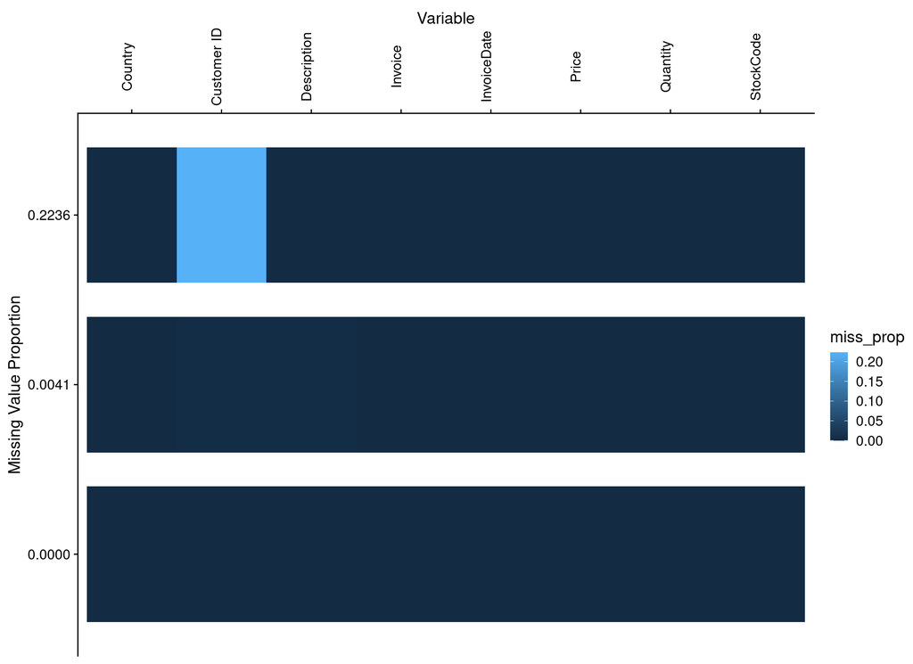

```r
row_count <- rawdata_tbl %>% nrow()

missing_plot_tbl <- rawdata_tbl %>%
  mutate_all(function(x) x %>% are_na() %>% vec_cast(integer())) %>%
  mutate(label = pmap_chr(., str_c)) %>%
  group_by(label) %>%
  summarise_all(list(sum)) %>%
  arrange(desc(label)) %>%
  select(-label) %>%
  mutate(label_count = pmap_int(., pmax)) %>%
  gather('col', 'count', -label_count) %>%
  mutate(miss_prop   = count / row_count,
         group_label = sprintf('%6.4f', round(label_count / row_count, 4))
        )

ggplot(missing_plot_tbl) +
  geom_tile(aes(x = col, y = group_label, fill = miss_prop), height = 0.8) +
  scale_fill_continuous() +
  scale_x_discrete(position = 'top') +
  xlab("Variable") +
  ylab("Missing Value Proportion") +
  theme(axis.text.x = element_text(angle = 90))
```

This visualisation takes a little explaining.

Each row represents a combination of variables with simultaneous missing values. For each row in the graphic, the coloured entries show which particular variables are missing in that combination. The proportion of rows with that combination is displayed in both the label for the row and the colouring for the cells in the row.

## 2.4 Inspect High-level-count Categorical Variables

With the raw data loaded up we now remove obvious unique or near-unique variables that are not amenable to basic exploration and plotting.

```r
coltype_lst <- create_coltype_list(data_tbl)

catvar_valuecount_tbl <- data_tbl %>%
  summarise_at(coltype_lst$split$discrete, ~ .x %>% unique() %>% length()) %>%
  gather('var_name', 'level_count') %>%
  arrange(-level_count)

print(catvar_valuecount_tbl)
```

```
## # A tibble: 5 x 2
##   var_name    level_count
##   <chr>             <int>
## 1 invoice_id        53628
## 2 customer_id        5943
## 3 description        5656
## 4 stock_code         5304
## 5 country              43
```

```r
row_count <- nrow(data_tbl)

cat(str_c("Dataset has ", row_count, " rows\n"))
```

```
## Dataset has 1067371 rows
```

Now that we a table of the counts of all the categorical variables we can automatically exclude unique variables from the exploration, as the level count will match the row count.

```r
unique_vars <- catvar_valuecount_tbl %>%
  filter(level_count == row_count) %>%
  pull(var_name)

print(unique_vars)
```

```
## character(0)
```

```r
explore_data_tbl <- data_tbl %>%
  select(-one_of(unique_vars))
```

Having removed the unique identifier variables from the dataset, we may also wish to exclude categoricals with high level counts also, so we create a vector of those variable names.

```r
highcount_vars <- catvar_valuecount_tbl %>%
  filter(level_count >= dataexp_level_exclusion_threshold,
         level_count < row_count) %>%
  pull(var_name)

cat(str_c(highcount_vars, collapse = ', '))
```

```
## invoice_id, customer_id, description, stock_code
```

We now can continue doing some basic exploration of the data. We may also choose to remove some extra columns from the dataset.

```r
### You may want to comment out these next few lines to customise which
### categoricals are kept in the exploration.
drop_vars <- c(highcount_vars)

if(length(drop_vars) > 0) {
  explore_data_tbl <- explore_data_tbl %>%
      select(-one_of(drop_vars))

  cat(str_c(drop_vars, collapse = ', '))
}
```

```
## invoice_id, customer_id, description, stock_code
```

## 2.5 Write to Disk

```r
#data_tbl %>% write_csv(path = 'DATAEXPKS.csv')
```

# 3 Univariate Data Exploration

Now that we have loaded the data we can prepare it for some basic data exploration. We first exclude the variables that are unique identifiers or similar, and tehen split the remaining variables out into various categories to help with the systematic data exploration.

```r
coltype_lst <- create_coltype_list(explore_data_tbl)

print(coltype_lst)
```

```
## $split
## $split$continuous
## [1] "quantity" "price"
##
## $split$datetime
## [1] "invoice_date" "invoice_dttm"
##
## $split$discrete
## [1] "country"
##
## $split$logical
## [1] "missing_cust_id" "cancelled_tnx"
##
##
## $columns
##        quantity    invoice_date           price         country    invoice_dttm
##    "continuous"      "datetime"    "continuous"      "discrete"      "datetime"
## missing_cust_id   cancelled_tnx
##       "logical"       "logical"
```

## 3.1 Logical Variables

Logical variables only take two values: TRUE or FALSE. It is useful to see missing data as well though, so we also plot the count of those.

```
## --
## missing_cust_id
```

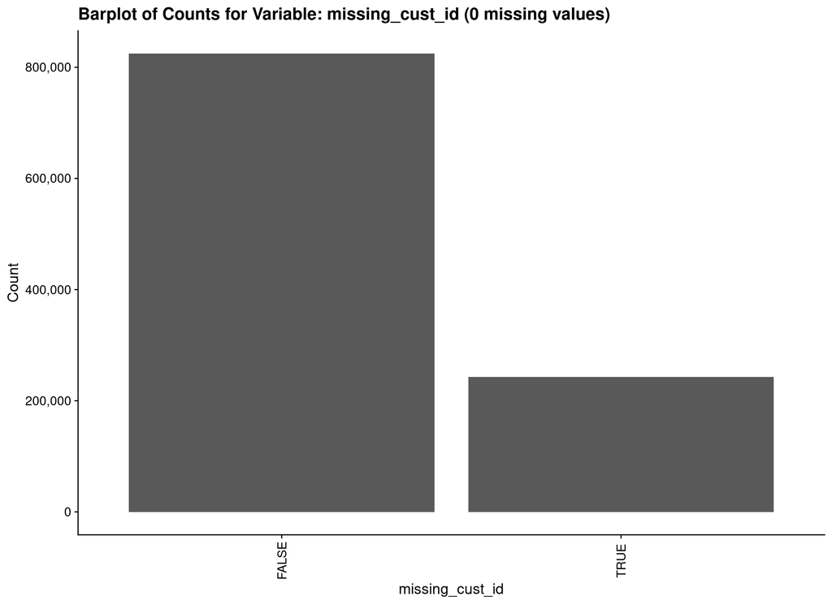

```
## --
## cancelled_tnx
```

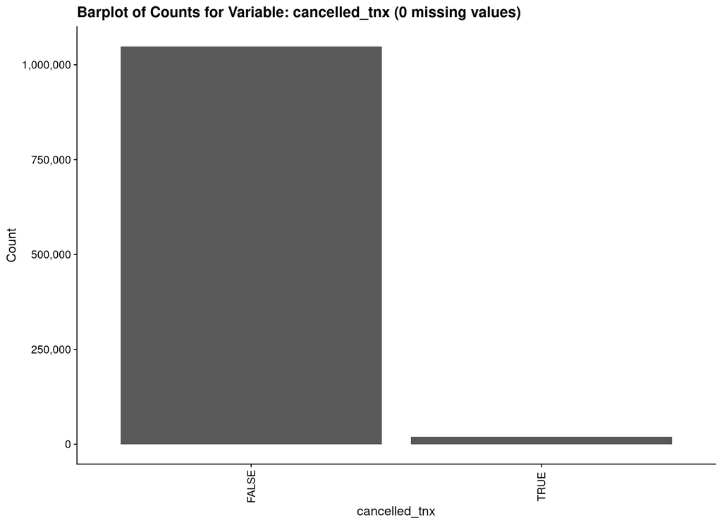

```r
logical_vars <- coltype_lst$split$logical

for(plot_varname in logical_vars) {
  cat("--\n")
  cat(str_c(plot_varname, '\n'))

  na_count <- explore_data_tbl %>% pull(!! plot_varname) %>% are_na() %>% sum()

  explore_plot <- ggplot(explore_data_tbl) +
    geom_bar(aes(x = !! sym(plot_varname))) +
    xlab(plot_varname) +
    ylab("Count") +
    scale_y_continuous(labels = comma) +
    ggtitle(str_c('Barplot of Counts for Variable: ', plot_varname,
                  ' (', na_count, ' missing values)')) +
    theme(axis.text.x = element_text(angle = 90, vjust = 0.5))

  plot(explore_plot)
}
```

## 3.2 Numeric Variables

Numeric variables are usually continuous in nature, though we also have integer data.

```
## --
## quantity
##      Min.   1st Qu.    Median      Mean   3rd Qu.      Max.
## -80995.00      1.00      3.00      9.94     10.00  80995.00
```

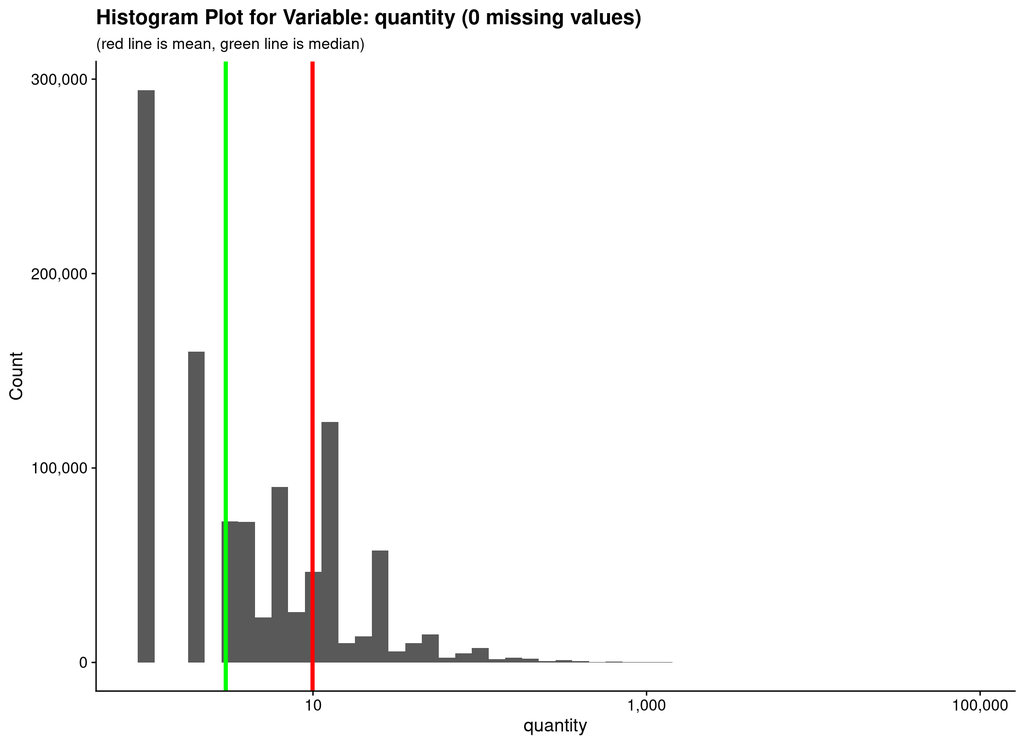

```
## --
## price
##      Min.   1st Qu.    Median      Mean   3rd Qu.      Max.
## -53594.36      1.25      2.10      4.65      4.15  38970.00
```

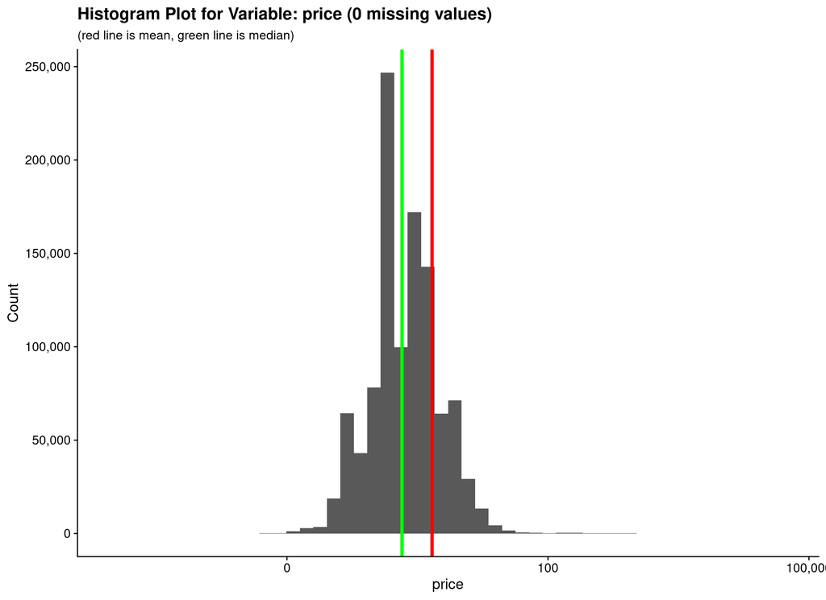

```r
numeric_vars <- coltype_lst$split$continuous

for(plot_varname in numeric_vars) {
  cat("--\n")
  cat(str_c(plot_varname, '\n'))

  plot_var <- explore_data_tbl %>% pull(!! plot_varname)
  na_count <- plot_var %>% are_na() %>% sum()

  plot_var %>% summary %>% print

  explore_plot <- ggplot(explore_data_tbl) +
    geom_histogram(aes(x = !! sym(plot_varname)), bins = dataexp_hist_bins_count) +
    geom_vline(xintercept = mean  (plot_var, na.rm = TRUE), colour = 'red',   size = 1.5) +
    geom_vline(xintercept = median(plot_var, na.rm = TRUE), colour = 'green', size = 1.5) +
    xlab(plot_varname) +
    ylab("Count") +
    scale_x_log10(labels = comma) +
    scale_y_continuous(labels = comma) +
    ggtitle(str_c('Histogram Plot for Variable: ', plot_varname,
                  ' (', na_count, ' missing values)'),
            subtitle = '(red line is mean, green line is median)')

  print(explore_plot)
}
```

## 3.3 Categorical Variables

Categorical variables only have values from a limited, and usually fixed, number of possible values

```
## --
## country
```

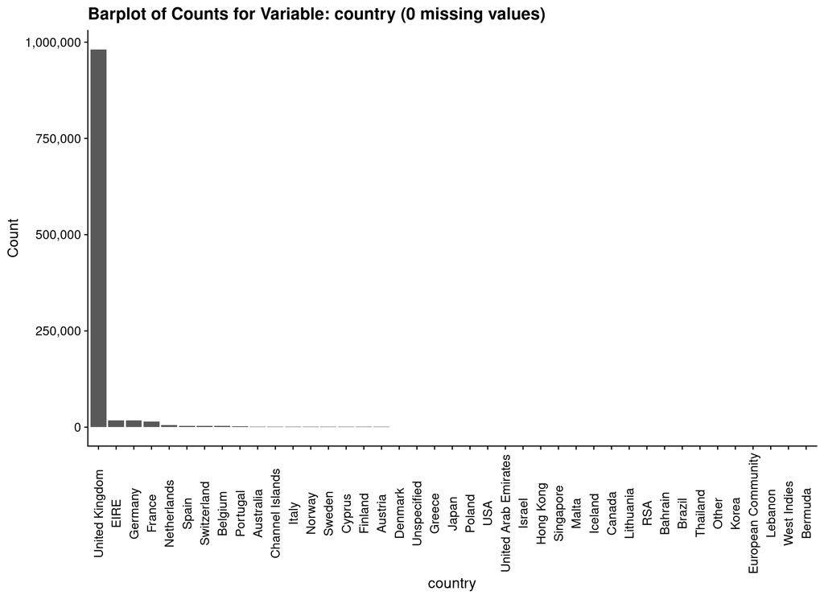

```r
categorical_vars <- coltype_lst$split$discrete

for(plot_varname in categorical_vars) {
  cat("--\n")
  cat(str_c(plot_varname, '\n'))

  na_count <- explore_data_tbl %>% pull(!! plot_varname) %>% are_na() %>% sum()

  plot_tbl <- explore_data_tbl %>%
    pull(!! plot_varname) %>%
    fct_lump(n = dataexp_cat_level_count) %>%
    fct_count()

  explore_plot <- ggplot(plot_tbl) +
    geom_bar(aes(x = fct_reorder(f, -n), weight = n)) +
    xlab(plot_varname) +
    ylab("Count") +
    scale_y_continuous(labels = comma) +
    ggtitle(str_c('Barplot of Counts for Variable: ', plot_varname,
                  ' (', na_count, ' missing values)')) +
    theme(axis.text.x = element_text(angle = 90, vjust = 0.5))

  plot(explore_plot)
}
```

## 3.4 Date/Time Variables

Date/Time variables represent calendar or time-based data should as time of the day, a date, or a timestamp.

```
## --
## invoice_date
##         Min.      1st Qu.       Median         Mean      3rd Qu.         Max.
## "2009-12-01" "2010-07-09" "2010-12-07" "2011-01-02" "2011-07-22" "2011-12-09"
```

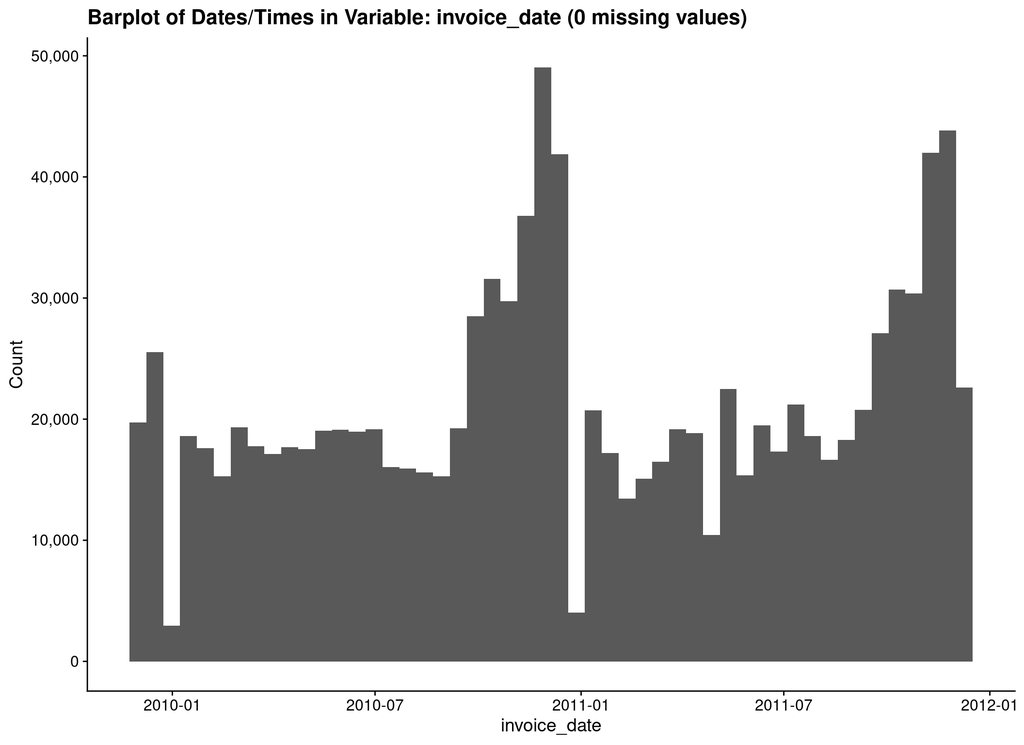

```
## --
## invoice_dttm
##                  Min.               1st Qu.                Median
## "2009-12-01 07:45:00" "2010-07-09 09:46:00" "2010-12-07 15:28:00"
##                  Mean               3rd Qu.                  Max.
## "2011-01-02 21:13:55" "2011-07-22 10:23:00" "2011-12-09 12:50:00"
```

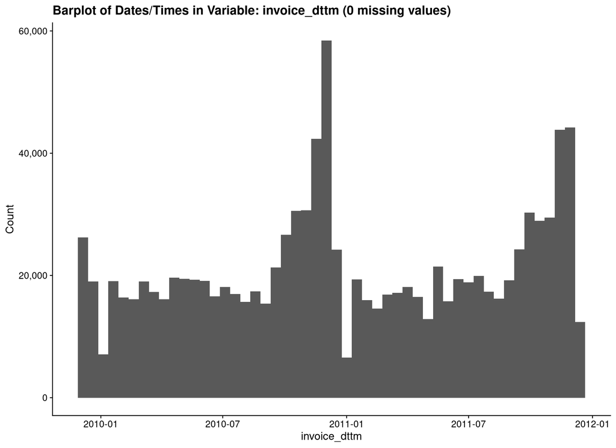

```r
datetime_vars <- coltype_lst$split$datetime

for(plot_varname in datetime_vars) {
  cat("--\n")
  cat(str_c(plot_varname, '\n'))

  plot_var <- explore_data_tbl %>% pull(!! plot_varname)
  na_count <- plot_var %>% are_na() %>% sum()

  plot_var %>% summary() %>% print()

  explore_plot <- ggplot(explore_data_tbl) +
    geom_histogram(aes(x = !! sym(plot_varname)), bins = dataexp_hist_bins_count) +
    xlab(plot_varname) +
    ylab("Count") +
    scale_y_continuous(labels = comma) +
    ggtitle(str_c('Barplot of Dates/Times in Variable: ', plot_varname,
                  ' (', na_count, ' missing values)'))

  plot(explore_plot)
}
```

# 4 Bivariate Data Exploration

We now move on to looking at bivariate plots of the data set.

## 4.1 Facet Plots on Variables

A natural way to explore relationships in data is to create univariate visualisations facetted by a categorical value.

```r
### _TEMPLATE_
### facet_varname <- ''
facet_varname <- 'missing_cust_id'


dataexp_facet_count_max <- 3
```

### 4.1.1 Logical Variables

For logical variables we facet on barplots of the levels, comparing TRUE, FALSE and missing data.

```
## --
## cancelled_tnx
```

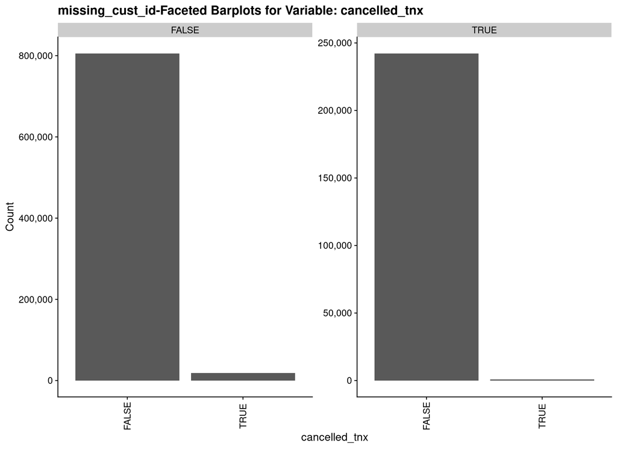

```r
logical_vars <- logical_vars[!logical_vars %in% facet_varname]


for(plot_varname in logical_vars) {
  cat("--\n")
  cat(str_c(plot_varname, '\n'))

  plot_tbl <- data_tbl %>% filter(!are_na(!! plot_varname))

  explore_plot <- ggplot(plot_tbl) +
    geom_bar(aes(x = !! sym(plot_varname))) +
    facet_wrap(facet_varname, scales = 'free') +
    xlab(plot_varname) +
    ylab("Count") +
    scale_y_continuous(labels = comma) +
    ggtitle(str_c(facet_varname, '-Faceted Barplots for Variable: ', plot_varname)) +
    theme(axis.text.x = element_text(angle = 90, vjust = 0.5))

  plot(explore_plot)
}
```

### 4.1.2 Numeric Variables

For numeric variables, we facet on histograms of the data.

```
## --
## quantity
```

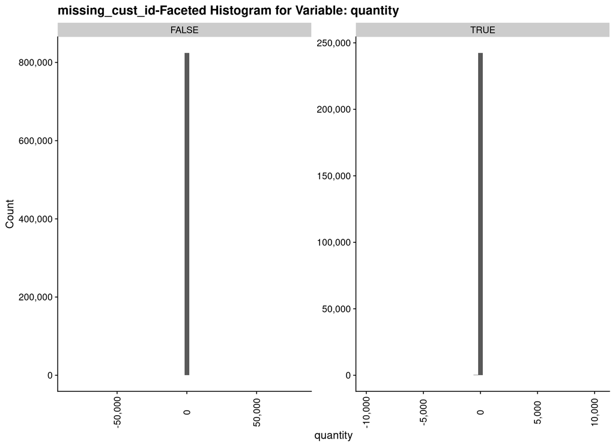

```
## --
## price
```

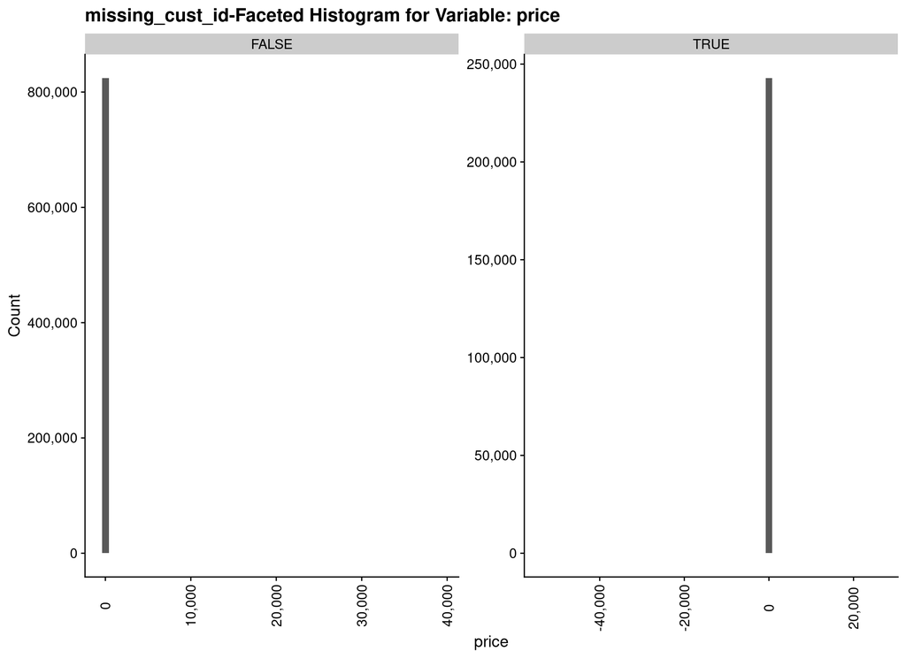

```r
for(plot_varname in numeric_vars) {
  cat("--\n")
  cat(str_c(plot_varname, '\n'))

  plot_tbl <- data_tbl %>% filter(!are_na(!! plot_varname))

  explore_plot <- ggplot(plot_tbl) +
    geom_histogram(aes(x = !! sym(plot_varname)), bins = dataexp_hist_bins_count) +
    facet_wrap(facet_varname, scales = 'free') +
    xlab(plot_varname) +
    ylab("Count") +
    scale_x_continuous(labels = comma) +
    scale_y_continuous(labels = comma) +
    ggtitle(str_c(facet_varname, '-Faceted Histogram for Variable: ', plot_varname)) +
    theme(axis.text.x = element_text(angle = 90, vjust = 0.5))

  print(explore_plot)
}
```

### 4.1.3 Categorical Variables

We treat categorical variables like logical variables, faceting the barplots of the different levels of the data.

```
## --
## country
```

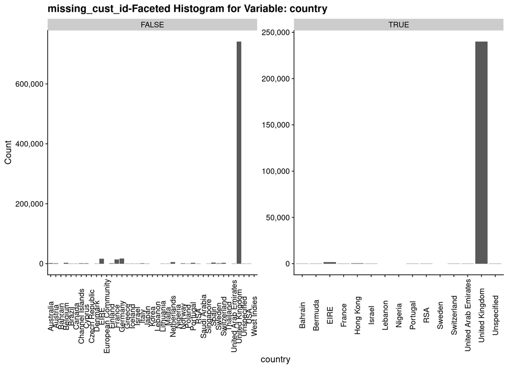

```r
categorical_vars <- categorical_vars[!categorical_vars %in% facet_varname]

for(plot_varname in categorical_vars) {
  cat("--\n")
  cat(str_c(plot_varname, '\n'))

  plot_tbl <- data_tbl %>% filter(!are_na(!! plot_varname))

  explore_plot <- ggplot(plot_tbl) +
    geom_bar(aes(x = !! sym(plot_varname))) +
    facet_wrap(facet_varname, scales = 'free') +
    xlab(plot_varname) +
    ylab("Count") +
    scale_y_continuous(labels = comma) +
    ggtitle(str_c(facet_varname, '-Faceted Histogram for Variable: ', plot_varname)) +
    theme(axis.text.x = element_text(angle = 90, vjust = 0.5))

  plot(explore_plot)
}
```

### 4.1.4 Date/Time Variables

Like the univariate plots, we facet on histograms of the years in the dates.

```
## --
## invoice_date
```

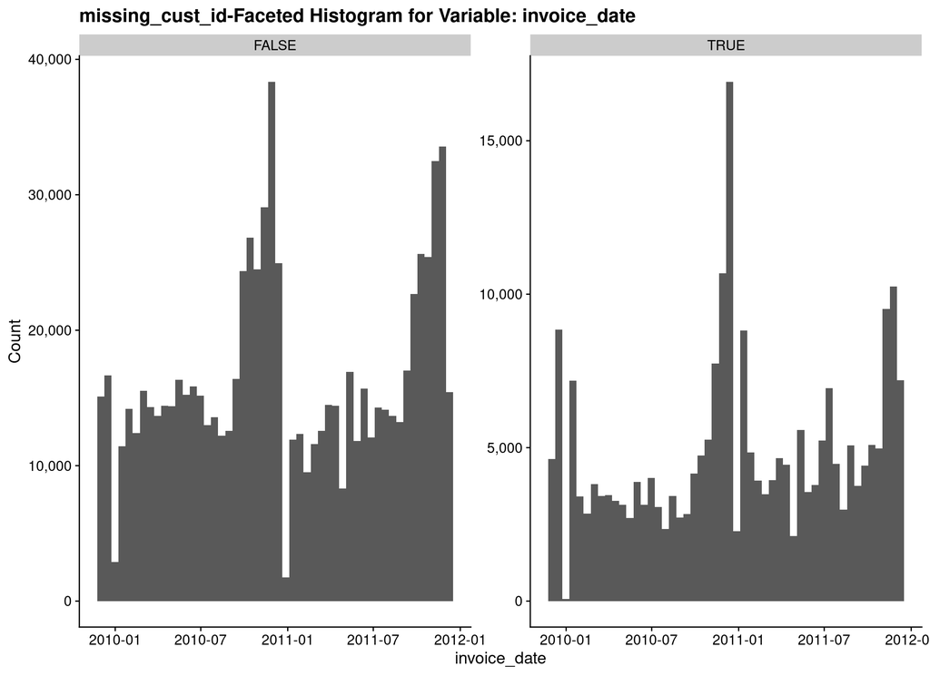

```
## --
## invoice_dttm
```

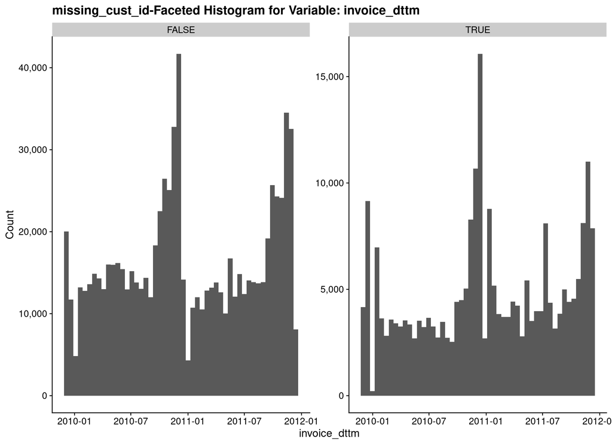

```r
for(plot_varname in datetime_vars) {
  cat("--\n")
  cat(str_c(plot_varname, '\n'))

  plot_tbl <- data_tbl %>% filter(!are_na(!! plot_varname))

  explore_plot <- ggplot(plot_tbl) +
    geom_histogram(aes(x = !! sym(plot_varname)), bins = dataexp_hist_bins_count) +
    facet_wrap(facet_varname, scales = 'free') +
    xlab(plot_varname) +
    ylab("Count") +
    scale_y_continuous(labels = comma) +
    ggtitle(str_c(facet_varname, '-Faceted Histogram for Variable: ', plot_varname))

  plot(explore_plot)
}
```